# Coursework Report

*N* removed NAs: 2

*N* removed typo: 1

*N* removed <18: 24

*N* total clean: 123

| Group | *N* | *M*<sub>age</sub> | *M*<sub>rating</sub> |
| --- | --- | --- | --- |
| Control | 59 | 20.73 | 5.78 |
| Experim | 64 | 20.91 | 6.41 |

**Main analysis results**

*t*(121) = -4.17, *p* < .001

[interactive chart not shown]

[figure not shown]

[interactive chart not shown]

# Coursework Report

Analysing Data, Spring 2020

# Methods

## Participants

Table 1 *Summary of Participant demographics by Experimental Condition*

| Group | *N* | *M*<sub>age(years)</sub> | *SD*<sub>age(years)</sub> | min. <sub>age(years)</sub> | max.<sub>age(years)</sub> |
| --- | --- | --- | --- | --- | --- |
| control | 59 | 20.73 | 2.18 | 18 | 27 |
| experimental | 64 | 20.91 | 2.19 | 18 | 26 |

## Design

Inspired by Elliot et al. (2010), the present study explored whether the presence of the colour red increased a woman’s attraction to a black and white photograph of a man. Participants were randomly allocated to one of two experimental conditions, each studying the influence of either a red or white background on perceived attractiveness of a photograph. In the experimental condition, participants were presented with three different black and white photographs (6inch X 4inch) of Caucasian, brunette men wearing a plain shirt, selected from Corneille, Monin & Pleyers’ (2005) set of standard photographs. These photographs were placed on a red background (8inch X 11inch) and participants were subsequently asked to rate the man’s attractiveness on a scale of 1-10 where a higher score indicated higher attractiveness. Within the control condition, participants followed the same process, however instead of a red background, the photographs were presented on a white, neutral background.

From these three scores produced by the participants, we calculated the mean score that they rated the photographs in their condition and furthermore, compared the overall mean rating between the two conditions. We then performed an independent-samples *t* -test to analyse whether the study’s findings of the extent to which colour condition influences rating of attractiveness are significant.

# Results

The present study investigated whether participants would give different ratings of a man’s attractiveness depending on whether he was presented on a red or white background, and used an independent measures *t* -test to analyse these results. Table 2 presents the mean rating of attractiveness (out of a possible 10) given in each condition.

Table 2 *Mean Attractiveness Rating by Condition*

| Group | *N* | Mean Rating | *SD*<sub>MeanRating</sub> |
| --- | --- | --- | --- |
| control | 59 | 5.78 | 0.82 |
| experimental | 64 | 6.41 | 0.84 |

As predicted in the alternative hypothesis, the analysis indicated that the presence of the colour red when looking at a monochrome photograph of a man increased mean ratings of attractiveness (*M* = 6.41) than photographs shown on a white background (*M* = 5.78). With a p value of < .001, we can therefore assume the difference between the means of each condition is significant (*M*<sub>diff</sub> = 0.63, 95% CI [-0.33, -0.92], *t* (121) = -4.17, *p* = 0.0000568 (p < .001)).

Figure 1 visualises the findings that show the influence of the colour red as a background to a black and white photograph on its mean rated attractiveness. This plot shows the mean rating of attractiveness given in the control condition where the photographs were presented on a white background (*M* = 5.78), was significantly lower than the mean rating given for the black and white photographs that were presented on a red background (*M* = 6.41).

Figure 1: *A means plot of composite scores by Condition*

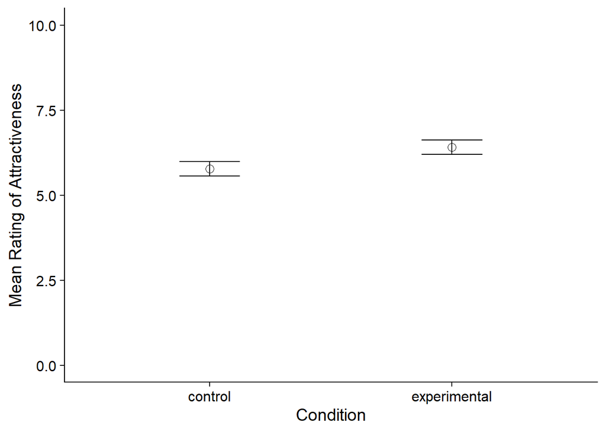

Thus, we can reject the Null Hypothesis, and accept the alternative hypothesis that states that the true different in means is not equal to 0 and therefore, we can conclude that the presence of the colour red is successful in increasing a woman’s rating of attractiveness of photographs of men.

# Discussion

The present study provides support for the hypothesis that stated that the colour red as a background for a photograph increases the rating of attractiveness that the photograph receives in comparison to a photograph shown on a white background. This effect was observed by presenting a control group (white) and an experimental group (red) with black and white photographs of similar looking males placed on either a white or red background. Our results supported the present hypothesis, discovering that the mean rating of attractiveness for a photograph shown on a red background was 6.41 out of a possible 10, whereas photographs displayed on a plain, white background was significantly lower at a mean rating of just 5.78. Furthermore, we conducted a statistical analysis of our results which shows that our results were significant, thus supporting our alternative hypothesis.

Therefore, it can now be assumed from our research that the presence of the colour red will increase a woman’s perceived physical attraction to a man. However, it should be noted that in the present study, the effect of the colour red, although significant, was not as high as previous studies have found (e.g. Elliot et al., 2010 and Gueguen (2012). This could have been a result of issues with participant data earlier on, resulting in the removal of a rather significant percentage of our sample, perhaps reducing its generalisability. To overcome this, it could be beneficial to attempt a replicate of the present study, using a considerably larger sample group in order to allow room for potential exclusion of a selection of participants for absence of vital data.

We live in a society where there is a large focus on people’s attractiveness. It has an effect on our relationships (Sangrador and Yela, 2000), our trust levels (Brundage et al., 1976) and our careers (Yates et al., 2017). The present study therefore suggests that as the colour red increases our perceived attractiveness, if we use this to our advantage and wear a red shirt to a first date or to a job interview, it can therefore perhaps increase our success rate in these additional aspects of our life. This theory could perhaps provide an interesting area of research for the future. Alternatively, the more knowledgeable we become on this topic as a society, may encourage people to understand how easily and perhaps unethically influenced we are by external factors, and we could work towards making more of a conscious effort of ignoring these in the future.

In closing, the present study has been successful in providing support towards the theory that the presence of the colour red increases a woman’s perceived attractiveness of a man and furthermore, opens a variety of promising future research standpoints that could contribute to personal success in many aspects of our lives such as our relationships and our careers.

# References

Brundage, L. E., Derlega, V. J., & Cash, T. F. (1976). The effects of physical attractiveness and need for approval on self-disclosure. Personality and Social Psychology Bulletin, 3(1), 63-66.

Corneille, O., Monin, B., & Pleyers, G. (2005). Is positivity a cue or a response option? Warm glow vs evaluative matching in the familiarity for attractive and not-so-attractive faces. Journal of Experimental Social Psychology, 41(4), 431-437.

Elliot, A. J., Niesta Kayser, D., Greitemeyer, T., Lichtenfeld, S., Gramzow, R. H., Maier, M. A., & Liu, H. (2010). Red, rank, and romance in women viewing men. Journal of Experimental Psychology: General, 139(3), 399.

Guéguen*, N. (2012). Color and women hitchhikers’ attractiveness: Gentlemen drivers prefer red. Color Research & Application, 37(1), 76-78.

Sangrador, J. L., & Yela, C. (2000). ‘What is beautiful is loved’: Physical attractiveness in love relationships in a representative sample. Social Behavior and Personality: an international journal, 28(3), 207-218.

Yates, J., Hooley, T., & Bagri, K. K. (2017). Good looks and good practice: the attitudes of career practitioners to attractiveness and appearance. British Journal of Guidance & Counselling, 45(5), 547-561.